# WorkTimeAnalysis

Samuel C. Zipper

1/1/2021

# Summary

Seems like every few months some random academic tweets about how they work a lot of hours, and then other people tweet about how they are doing fine despite working fewer hours. I’ve never been able to participate in these conversations because I don’t know how much I work, and also people rarely seem to have any actual data to support their claims about work (or lack thereof). So, I tracked my work at 30-minute intervals for [2019](https://docs.google.com/spreadsheets/d/1O4tB-IDLZUqP1I2ECJ9JnBOEDbQEoOwNLbbcBjrV4Tk/edit?usp=sharing) and [2020](https://docs.google.com/spreadsheets/d/1I4kUeZEEtup1e7Wd3PSqfBpaHyK6ntcL18Dz2zYSCfs/edit#gid=1890047702) to try and answer two questions:

1. How much do I work?
- *Quick answer: ~40-45 hrs/week, but almost every day*
2. When I do work, how do I spend my time?
- *Quick answer: about equal portions of research, meetings, and the variety of tasks (emails, etc.) I classify as ‘logistics’.*

The years analyzed (January 2019 - December 2020) had several important personal and professional changes including (i) going from a postdoc to a PI at a new institution (August 2019); (ii) working from home due to COVID (March 2020); (iii) and having our second kid (June 2020), so I also decided to look into whether my working time or activities changed through time.

# How much do I work?

Answering the first question (How much do I work?) is pretty simple; I can just add up all the hours I worked.

I sliced the data a few different ways.

Over the course of the two years, I worked 3908 hours, or an average of 37.9 hours per week - pretty close to the standard 40 hr work week. Sounds pretty good! Until, of course, you consider the fact that I took some vacations during this time, and also was on part-time leave for 3 months with the new baby, so I would have expected the average to be a bit lower.

Let’s see how the hour count varies week-to-week:

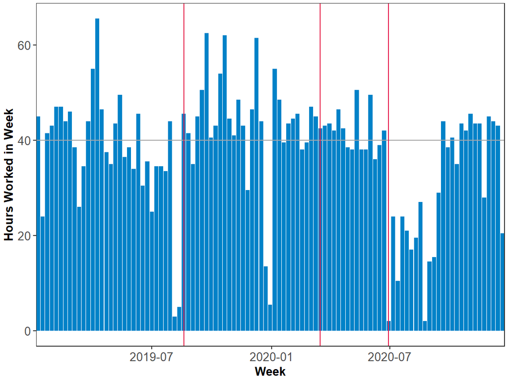

Pretty consistent overall, fluctuating around 40 +/- 5 hrs, with a median of 42 hours and a mode of 44 hours. The three vertical red lines correspond to starting my new job (August 2019), switching to work from home (March 2020), and the new baby (June 2020). Only the new baby seemed affect hours worked (we’ll look at allocation of time later), as I went on partial leave for 12 weeks.

But overall, **in a typical week I work between 40-45 hours**. Now, let’s take a look at the daily data.

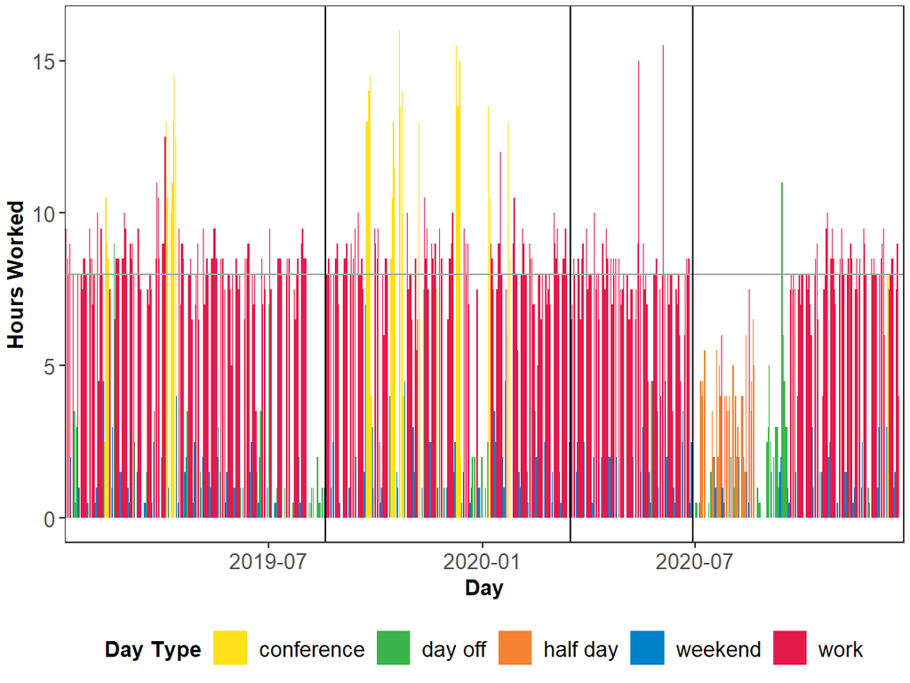

I’ve colored by the type of day. Pretty clear pattern - usually working right around 8 +/- 1 hours on work days, with the extreme highs mostly driven by conferences/workshops, and lower values on the weekends. This is also evident in a histogram of daily hours works:

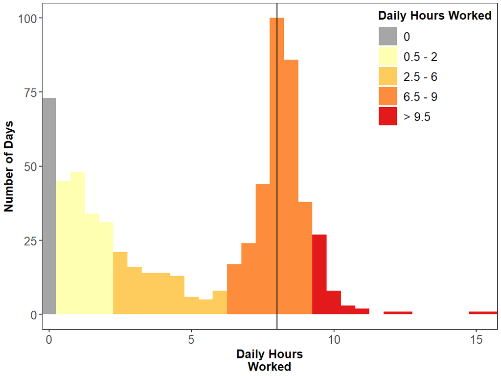

Now, how about that left side of the histogram - less than 75 days with 0 hours worked over the past two years? Yikes. In this time period alone, there were 205 weekend days and another 81 days off for holiday, vacation, parental leave, etc., meaning that I actually worked on 70% of my days off. Anecdotally, this is true - in the histogram we can see a large cluster of days < 2 hours, which is about the length of my kids’ nap time, and I will often sit on the couch and check some emails during weekend naps. This is confirmed by looking at hours worked broken down by day of week:

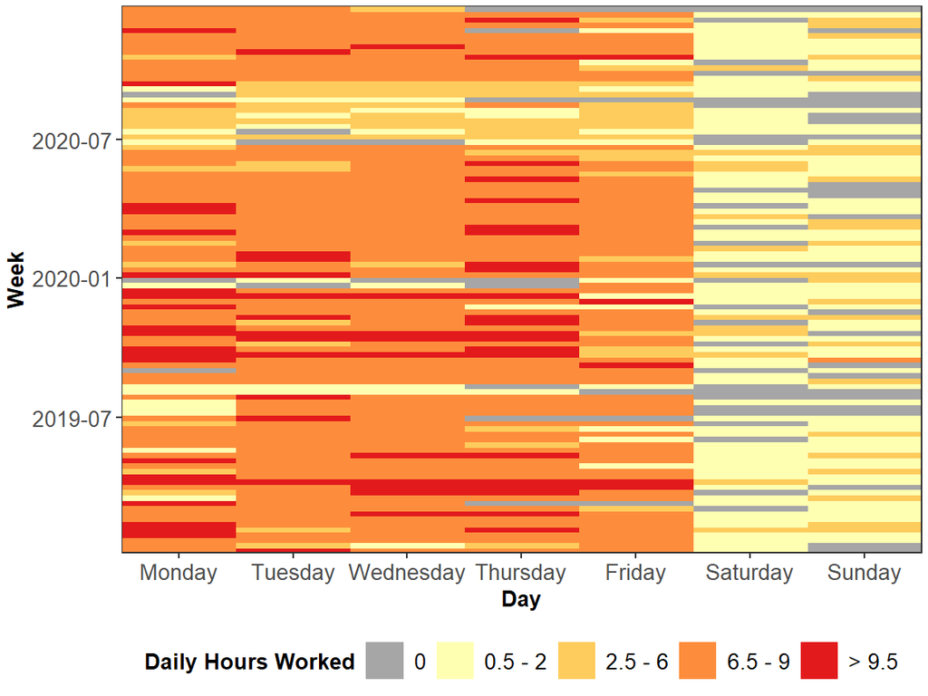

Interesting pattern - pretty clear that Mondays and Thursdays are the days when I tend to put in a bit of extra time.

So, to draw some conclusions:

So, my resolution from part 1 of the analysis: *quit doing small bits of work on the weekends because the potential detriment (overwork) is likely more than the gain (incremental progress on unimportant things).*